# Final Presentation

May 05, 2022 @ 02:44 PM

## Packages Used

I used tidyverse for data manipulation and plotting.

```r
library(tidyverse)
```

I need scales to format a percentage axis.

```r
library(scales)
```

To open and read files

```r
library(readr)
```

For my first visual

```r
library(treemap)
```

## Harry Potter Movies Dataset: Characters

I compiled my dataset by using the web site Kaggle [Harry Potter Movies Dataset](https://www.kaggle.com/datasets/maricinnamon/harry-potter-movies-dataset?resource=download). Then took the subset dataset for characters

The dataset was last updated 4 months ago, so some of the values may have changed between then and now.

**Variables in the Dataset:**

- `'Character ID'`: Assigned id number for each character
- `'Character Name'`: Character names from all Harry Potter movies
- `Species`: Characters creature type in Harry Potter movie(Human,Ghost,Centaur, Half-Human/Half-Giant, Werewolf, etc)
- `Gender`: The gender for each character (Female/Male)
- `House`: The sorted house for each charcter(Gryffindor, Slytherin, Ravenclaw, Hufflepuff,Beauxbatons Academy of Magic and Durmstrang Institute)
- `Patronus`: The patronus spirt gardiun for each character(Stag, Doe, Cat, Jack Russell Terrier,Otter, ect)
- `'Wand (Wood)`: wood type for each characters wand(Yew,Cherry,Holly,Vine and Elder)
- `'Wand (Core)`: core type of each charcters wand(Dragon Heartstring,Unicorn Hair,Phoenix Feather,Thestral Tail Hair, etc))

```
Rows: 166
Columns: 8
$ `Character ID`   <dbl> 1, 2, 3, 4, 5, 6, 7, 8, 9, 10, 11, 12, 13, 14, 15, 16…
$ `Character Name` <chr> "Harry Potter", "Ron Weasley", "Hermione Granger", "A…
$ Species          <chr> "Human", "Human", "Human", "Human", "Half-Human/Half-…
$ Gender           <chr> "Male", "Male", "Female", "Male", "Male", "Male", "Fe…
$ House            <chr> "Gryffindor", "Gryffindor", "Gryffindor", "Gryffindor…
$ Patronus         <chr> "Stag", "Jack Russell Terrier", "Otter", "Phoenix", N…
$ `Wand (Wood)`    <chr> "Holly", NA, "Vine", "Elder", "Oak", NA, "Fir", "Ceda…
$ `Wand (Core)`    <chr> "Phoenix Feather", NA, "Dragon Heartstring", "Thestra…
```

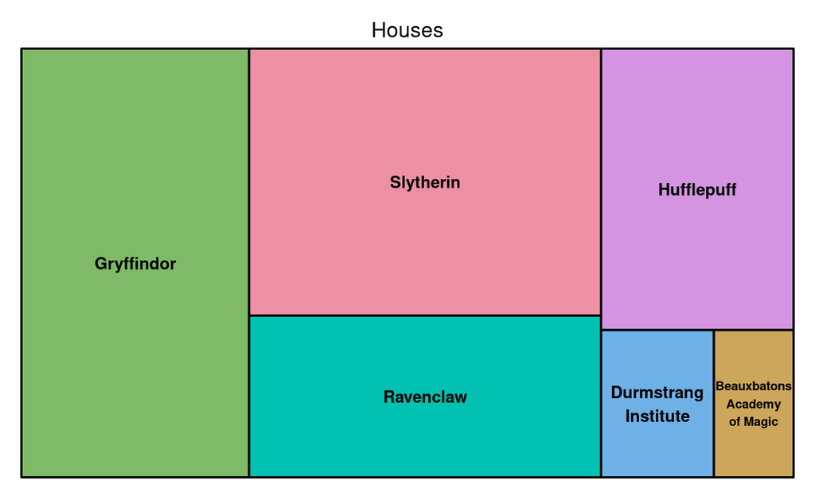

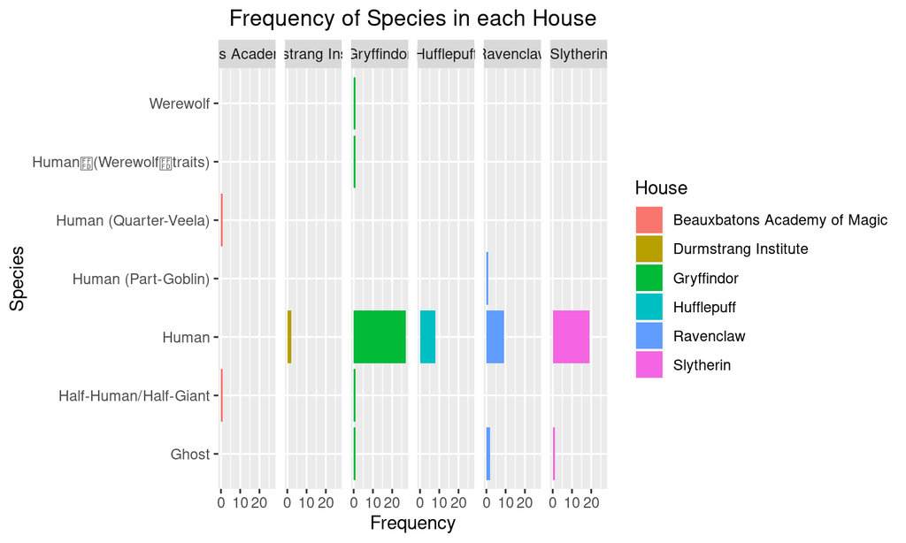

THANK YOU!